# R Notebook

#### Nuevas muertes

```r
summary(PENST$nuevas_muertes)
```

```
##    Min. 1st Qu.  Median    Mean 3rd Qu.    Max.
##     138    2955    8523    9614   17188   23285
```

```r
sd(PENST$nuevas_muertes)
```

```
## [1] 7807.277
```

La nueva muerte por mes tiene rango, media y mediana menor a los nuevos casos por mes, sin embargo, su desviación estándar también es menor por lo que se puede predecir que tendrá sus datos con una dispersión similar.

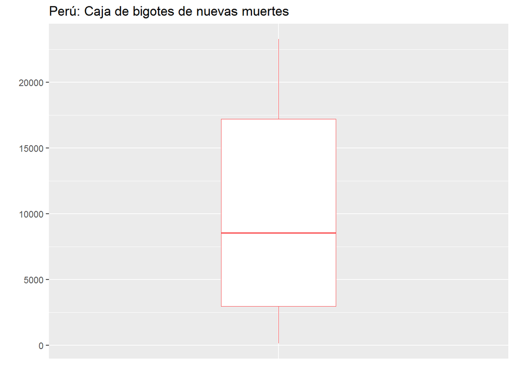

*Análisis*: En la gráfica se puede observar una compactación baja con respecto a las nuevas muertes registradas por covid-19 y una ausencia de datos atípicos por lo que el número de muertes tiene un rango un poco alto, sin embargo, no presenta cambios muy grandes. Por otro lado, al menos la mitad del número de muertes en los meses es menor a 8523.

#### Cantidad de vacunados

```r
summary(PENST$nuevas_vacunaciones)
```

```
##    Min. 1st Qu.  Median    Mean 3rd Qu.    Max.
##       0       0       0 1930015 3400472 8459637
```

```r
sd(PENST$nuevas_vacunaciones)
```

```
## [1] 2856363
```

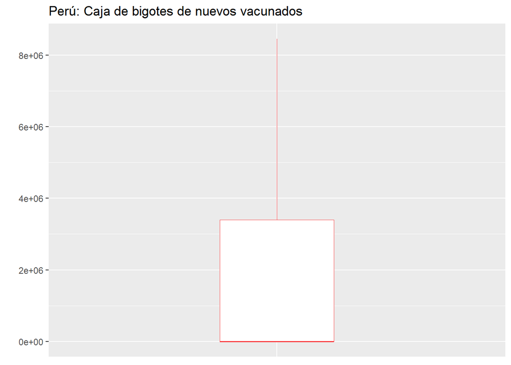

*Análisis*: En la gráfica se puede observar que la cantidad de nuevos vacunados al mes varía mucho, pero no de manera muy brusca porque el rango intercuartil es muy ancho y no hay señales o indicios de demasiados valores atípicos.

# Gráficos:

##: Estado actual de la pandemia

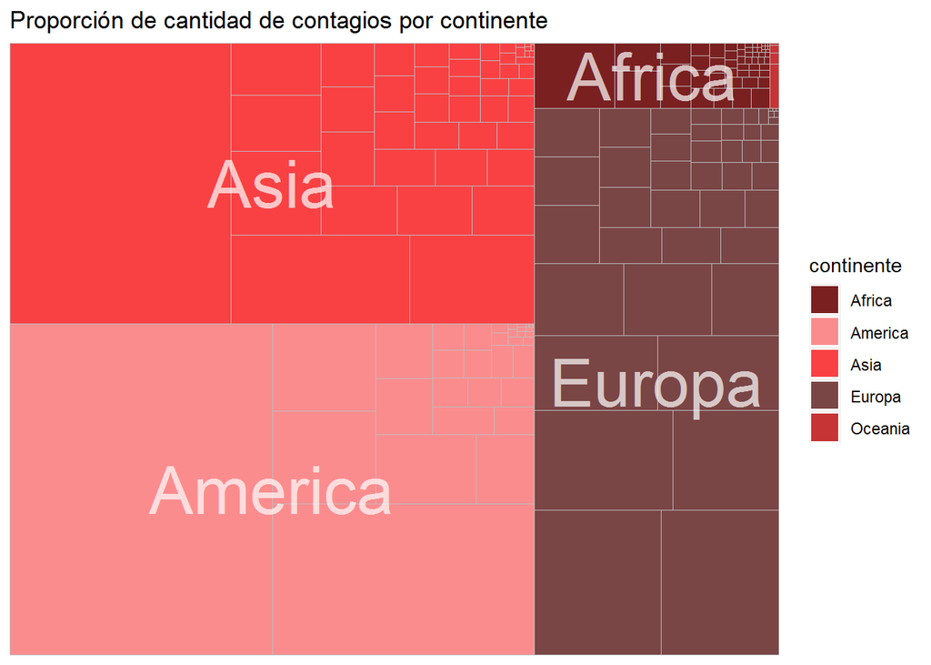

América (Norte, centro y sur) es el continente con mayor cantidad de casos detectados de Covid-19, seguido de Asia, y Europa.

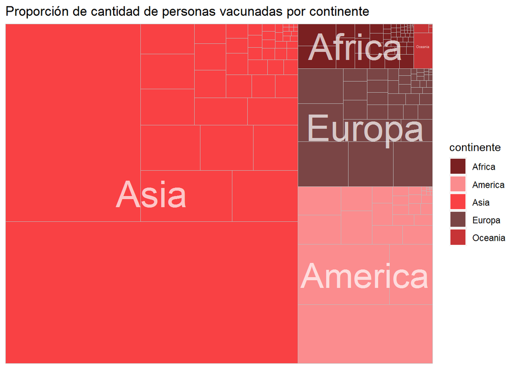

A pesar de que América supera a Asia en cantidad de casos detectados, es el continente de Asia quien cuenta con la mayor cantidad de vacunas aplicadas superando por bastante a los demás continentes.

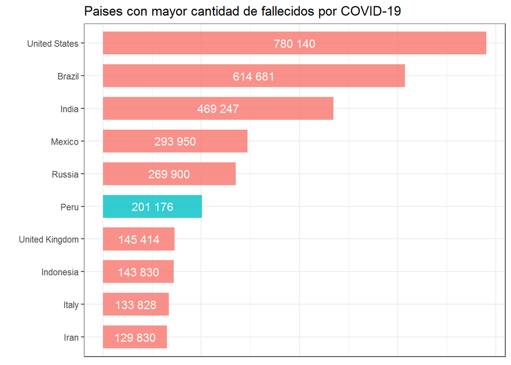

Perú se encuentra entre en el sexto lugar de países con mayor cantidad de fallecimientos por Covid-19 en el mundo. En los dos primeros puestos tenemos a Estados Unidos y Brasil.

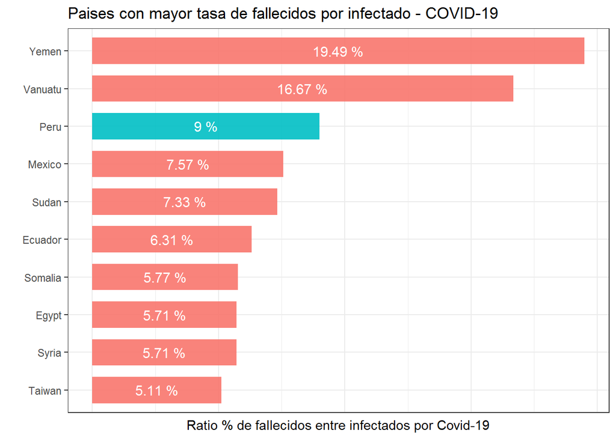

Como podemos observar en la gráfica, Perú tiene la tercera mayor cantidad de muertes por infectado durante la pandemia. Se podría indicar que un ciudadano peruano tiene más probabilidad de morir al contraer Covid que en otros países.

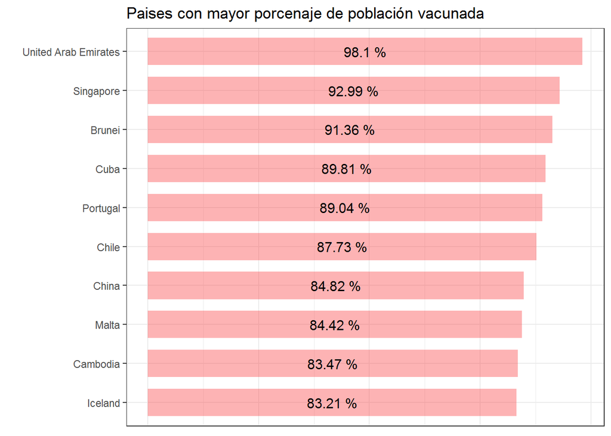

```
## [1] 0.6676106
```

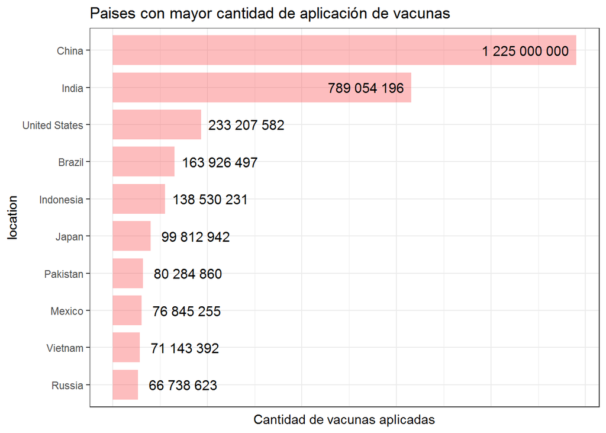

## Patrones

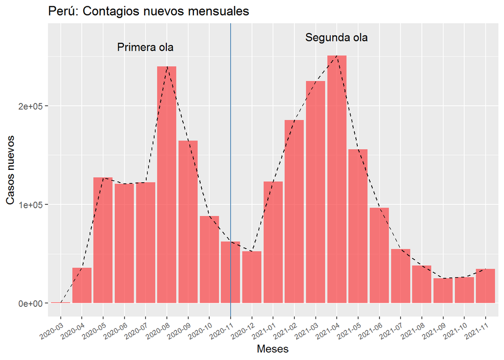

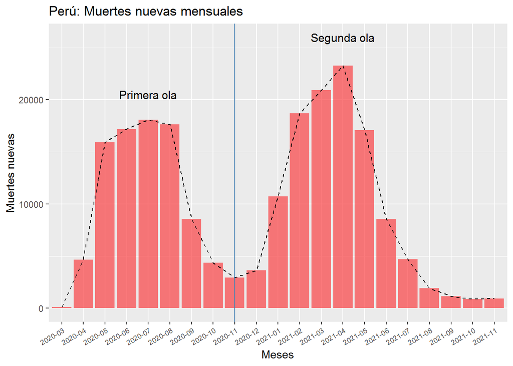

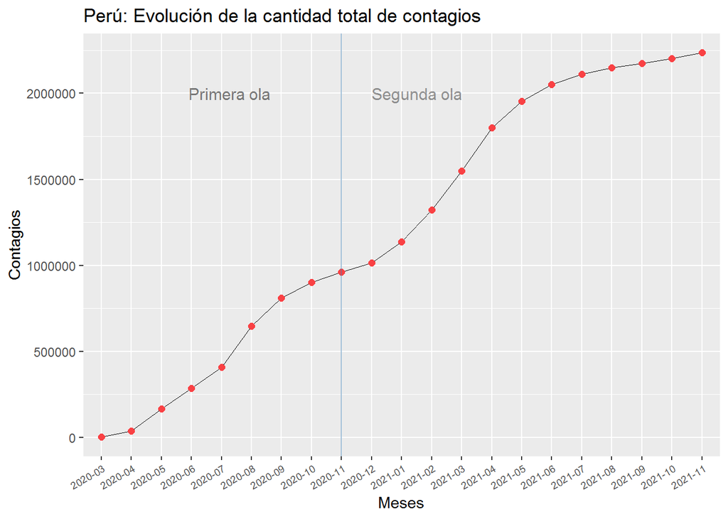

Podemos notar al final de cada ola un ligero aplanamiento en la curva del total de casos nuevos. Este aplanamiento es más evidente en los últimos meses.

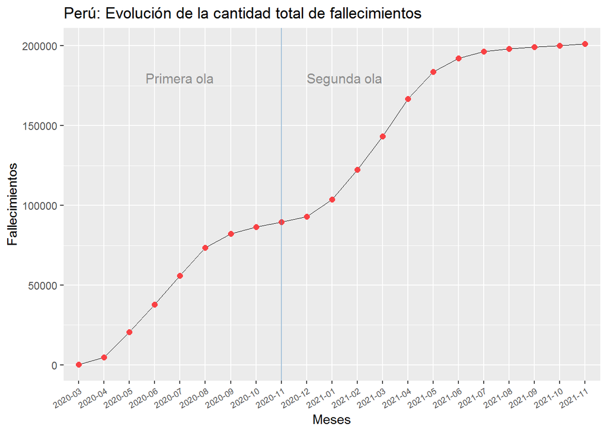

Notamos que la curva de cantidad de fallecidos se ha aplanado considerablemente en los últimos meses manteniéndose casi invariable en los 200 mil casos.

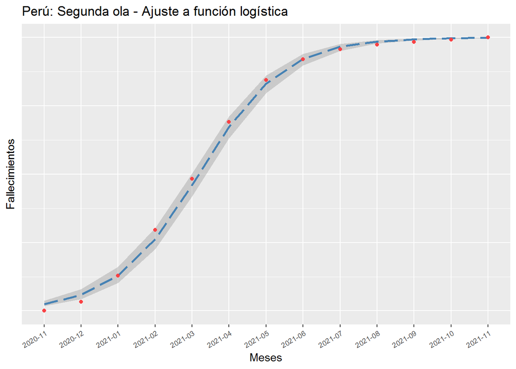

Como se puede observar la gráfica de fallecidos totales desde la segunda ola se ajusta bastante bien a una curva sigmoidea.

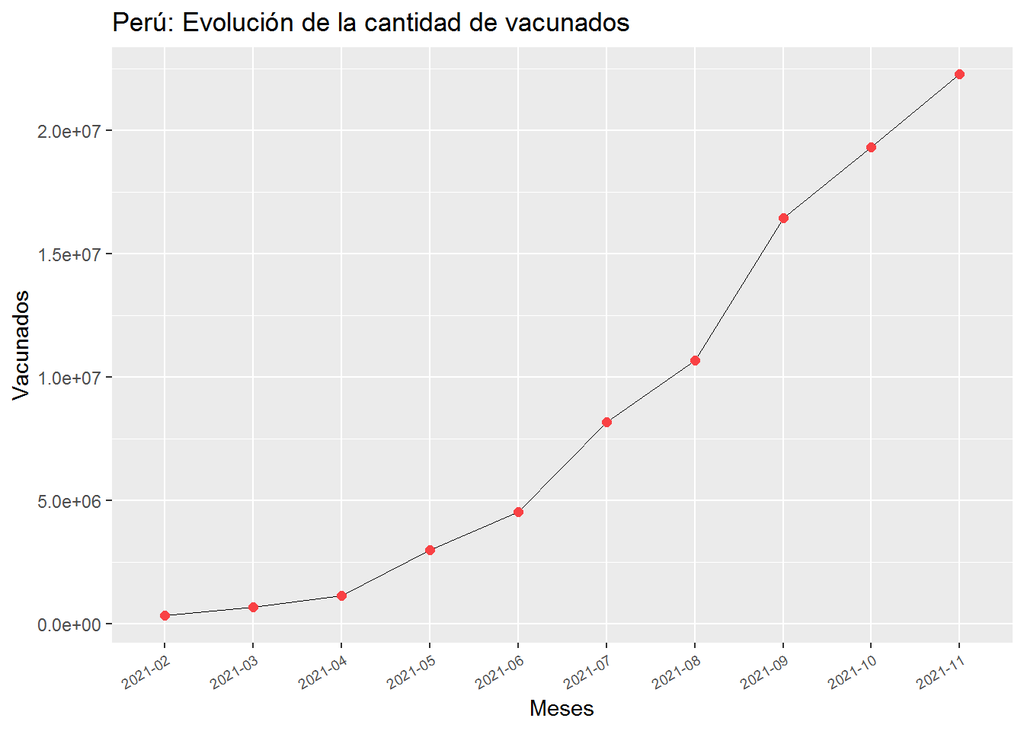

Perú empezó su campaña de vacunación en febrero del 2021. Como podemos observar en el gráfico la cantidad de vacunados aumenta rápidamente. En el siguiente gráfico podemos observar que la cantidad de nuevos fallecimientos también disminuye rápidamente en este periodo:

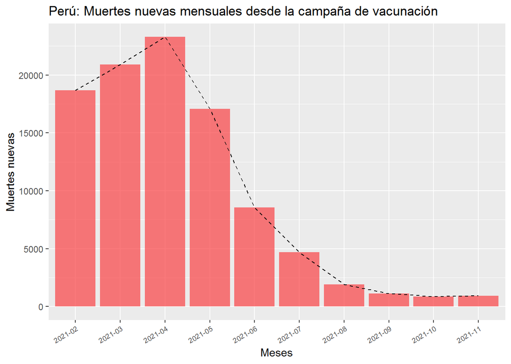

# Planteamiento de hipótesis

### ¿Es la vacuna un factor determinante para evitar el aumento de número de muertes por COVID-19?

Es sabido que la vacuna puede prevenir efectos graves en el paciente, por lo que podría evitar que el paciente pueda morir a causa de la enfermedad.

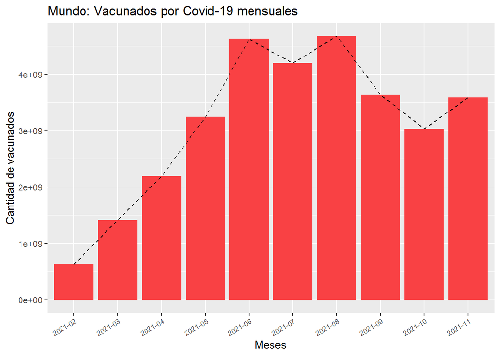

*Análisis:* Como observamos en el gráfico a finales del año 2020 en algunos países se empezaron las campañas de vacunación contra el COVID-19, yendo de esta manera en aumento el número de vacunados a nivel mundial.

Para poder responder nuestra hipótesis planteada decidimos primeramente relacionar el número de muertos a nivel mundial y luego concentrarlo en Perú, con lo cual obtuvimos los siguientes resultados

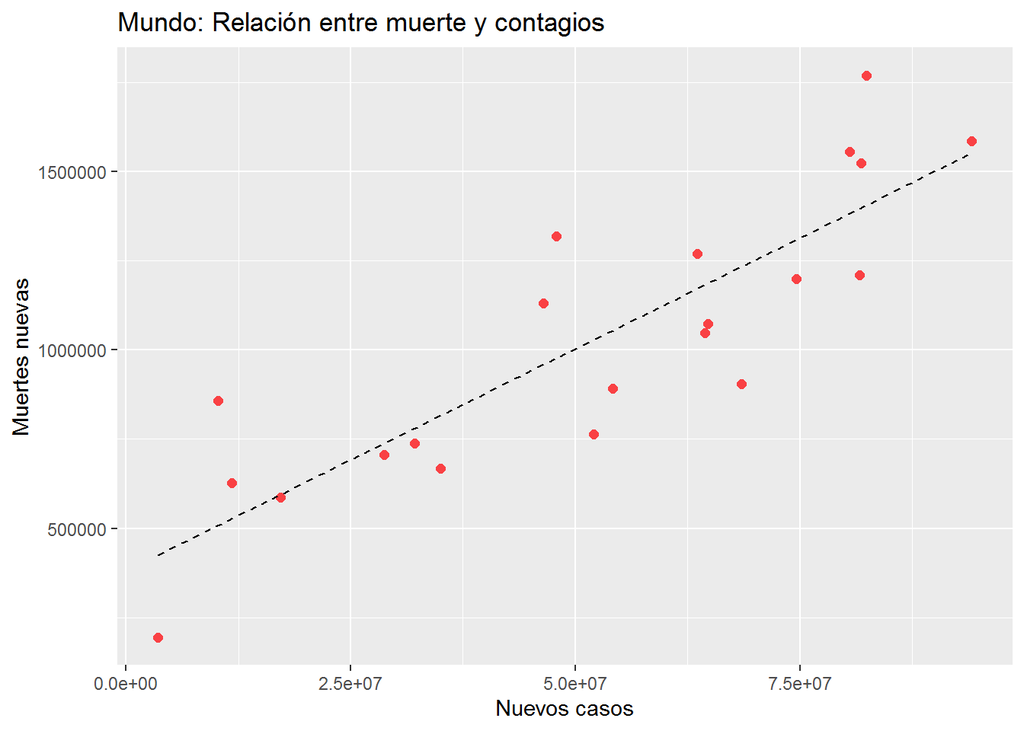

```
## [1] "Correlación:  0.86"
```

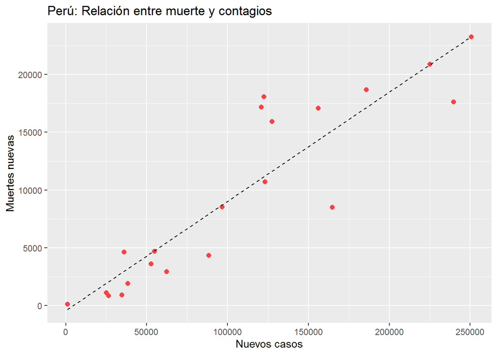

```
## [1] "Correlación:  0.91"
```

Por otro lado, con el gráfico presente podemos observar que conforme aparecen nuevos casos de COVID-19 en el país, la cantidad de muertes sigue en constante aumento, simulando casi una función lineal como muestra su línea de tendencia en el gráfico, lo cual también se reflejado en el valor de la correlación entre ambas variables.

Es por esto que nos planteamos si es que con el inicio de las vacunaciones a nivel mundial y en el país, el número de muertes iría descendiendo, ya que son creadas con este fin, el de evitar un mayor número de muertes. Es por esto que mostramos el siguiente gráfico desde que se iniciaron las campañas de vacunación en el país, relacionado con la cantidad de muertes que se presentan.

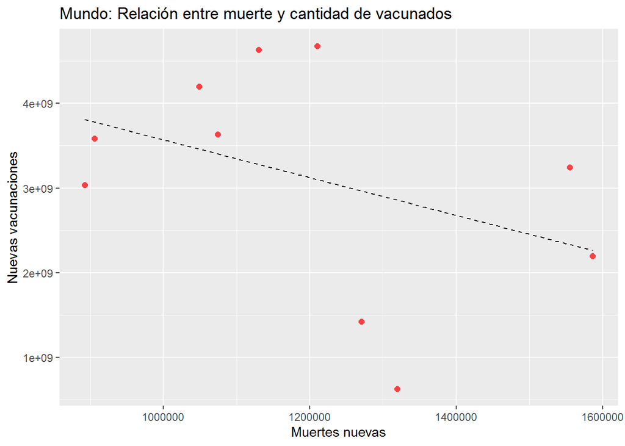

```
## [1] "Correlación:  -0.4"
```

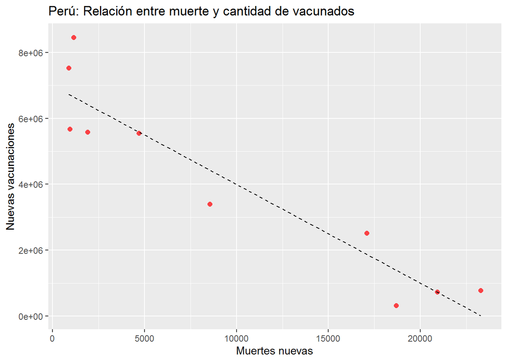

```
## [1] "Correlación:  -0.94"
```

### ¿Cuál es la relación de personas hospitalizadas y la cantidad de muertes?

Para responder a esta pregunta se analizarán las variables cantidad de personas hospitalizadas y cantidad de muertes, ambas establecidas en meses y finalmente la relación que existe entre ambas.

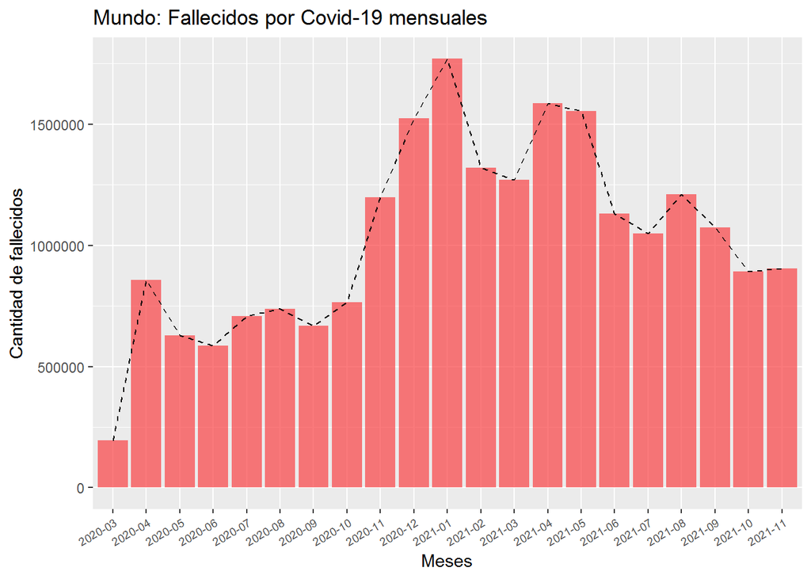

```
## [1] "Mayor cantidad de muertos por Covid-19 en el mundo ocurrió el 2021-01 afectando a: 1769971 personas"
```

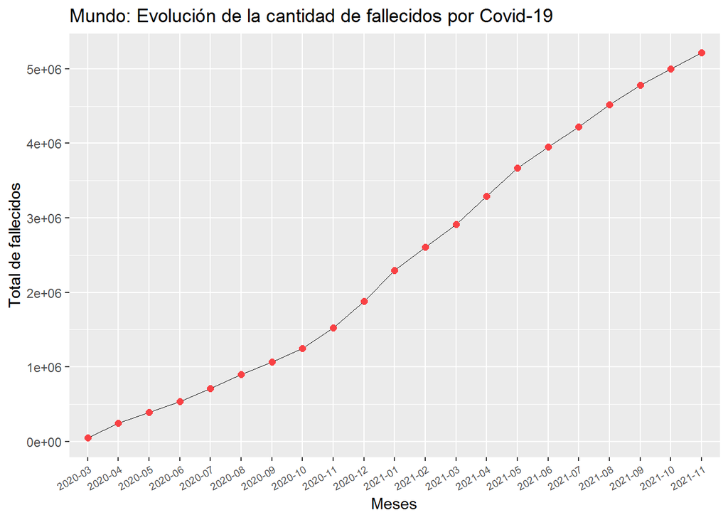

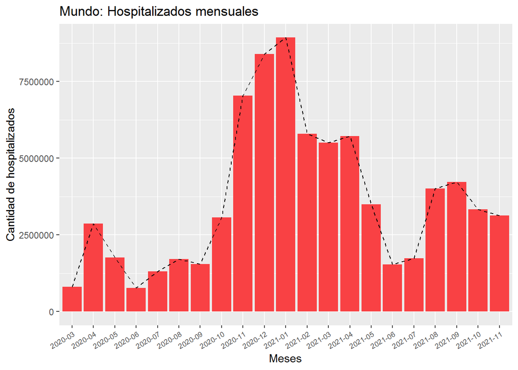

```
## [1] "Mayor cantidad de hospitalizados por Covid-19 en el mundo ocurrió el 2021-01 afectando a: 8934434 personas"
```

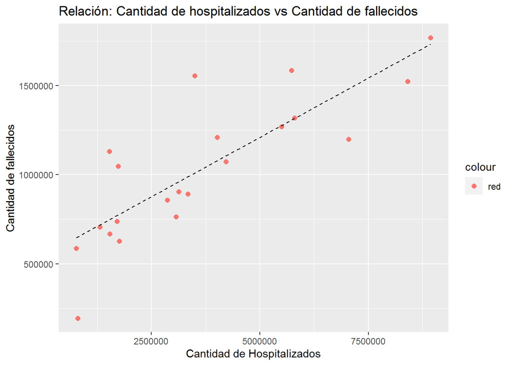

```
## [1] "Correlación:  0.82"
```